# Bank Users - Churn Prediction

## Description

### Background and Context

Businesses like banks that provide service have to worry about the problem of 'Churn' i.e. customers leaving and joining another service provider. It is important to understand which aspects of the service influence a customer's decision in this regard. Management can concentrate efforts on the improvement of service, keeping in mind these priorities.

### Objective

Given a Bank customer, build a neural network-based classifier that can determine `whether they will leave or not in the next 6 months`.

### Data Description

The case study is from an open-source dataset from Kaggle. The dataset contains 10,000 sample points with 14 distinct features such as CustomerId, CreditScore, Geography, Gender, Age, Tenure, Balance, etc.

#### Data Dictionary

- `CustomerId:` Unique ID which is assigned to each customer
- `Surname:` Last name of the customer
- `CreditScore:` It defines the credit history of the customer.
- `Geography:` A customer’s location
- `Gender:` It defines the Gender of the customer
- `Age:` Age of the customer
- `Tenure:` Number of years for which the customer has been with the bank
- `NumOfProducts:` It refers to the number of products that a customer has purchased through the bank.
- `Balance:` Account balance
- `HasCrCard:` It is a categorical variable that decides whether the customer has a credit card or not.
- `EstimatedSalary:` Estimated salary
- `isActiveMember:` It is a categorical variable that decides whether the customer is an active member of the bank or not ( Active member in the sense, using bank products regularly, making transactions, etc )
- `Excited:` It is a categorical variable that decides whether the customer left the bank within six months or not. It can take two values

  ```
                0=No ( Customer did not leave the bank )

                1=Yes ( Customer left the bank )
  ```

## Solution Approach

- **Understand given data from bank**
  - Check for Size/Duplicates/Null values/Sample data
- **Feature Elimination**
  - Remove features not reqd for churn prediction solution
- **Exploratory Data Analysis and Insights**
  - Univariate analysis
  - Bivariate analysis -
  - List all Key meaningful observations
- **Data pre-processing**
  - Prepare the data for analysis
  - Feature Engineering
  - Missing value Treatment
  - Outlier Treatment
- **Data preparation**
  - Split the target variable and predictors
  - Split the data into train and test
  - Data scaling
- **Model building & Model Performance Improvement**
  - Build Neural Network Model
  - Performance Tuned Model - Check Performance & Hyper Parameters Tuning
  - Model Performance Evaluation
- **Actionable Insights & Recommendations**
  - Business recommendations and insights
  - Conclusion and key takeaways

# Churn Prediction Solution

## Understand Given Data

Load given data `Dataset - bank.csv` to data frame and understand data, data type, data nature, features incuded, total records,data has any missing values or duplicate data, outliers.

Visualize data and and understand data range and detect outliers

### Loading necessary libraries for EDA

Load all standard python library packages.

#### Data Manipulation

- Numpy
- Pandas

#### Data Visualization

- matplotlib.pyplot
- seaborn

```python
# Colab setup style blackcellmagic
import os, sys, subprocess
if "google.colab" in sys.modules:
    cmd = "pip install --upgrade watermark blackcellmagic"
    process = subprocess.Popen(cmd.split(), stdout=subprocess.PIPE)
```

```python
# this will help in making the Python code more structured automatically
%load_ext blackcellmagic

import warnings

warnings.filterwarnings("ignore")

# Libraries to help with reading and manipulating data

import pandas as pd
import numpy as np

# Libraries to help with data visualization
import matplotlib.pyplot as plt
import seaborn as sns

# Removes the limit for the number of displayed columns
pd.set_option("display.max_columns", None)
# Sets the limit for the number of displayed rows
pd.set_option("display.max_rows", 200)
```

```
The blackcellmagic extension is already loaded. To reload it, use:
  %reload_ext blackcellmagic
```

## Load data to dataframe

Read given xlsx file `bank.csv` and load to data frame `bankdata`.

Load data based on environment, if Colab then load data from google drive else from local system

```python
%%time

if "google.colab" in sys.modules:
    from google.colab import drive
    # reading csv data given from bank and load to data frame
    drive.mount('/content/drive/')
    bank_data = pd.read_csv("/content/drive/My Drive/ML/Deep_Learning/project/bank.csv")
    # copying orignal data so that when changing data we dont lose original
    data = bank_data.copy()

else:
    # reading csv data given from bank and load to data frame
    bank_data = pd.read_csv("bank.csv")
    # copying orignal data so that when changing data we dont lose original
    data = bank_data.copy()
```

```
CPU times: user 25.3 ms, sys: 6.69 ms, total: 32 ms
Wall time: 805 ms
```

### View the first and last 5 rows of the dataset.

```python
data.head(5)
```

|  | RowNumber | CustomerId | Surname | CreditScore | Geography | Gender | Age | Tenure | Balance | NumOfProducts | HasCrCard | IsActiveMember | EstimatedSalary | Exited |
| --- | --- | --- | --- | --- | --- | --- | --- | --- | --- | --- | --- | --- | --- | --- |
| 0 | 1 | 15634602 | Hargrave | 619 | France | Female | 42 | 2 | 0.00 | 1 | 1 | 1 | 101348.88 | 1 |
| 1 | 2 | 15647311 | Hill | 608 | Spain | Female | 41 | 1 | 83807.86 | 1 | 0 | 1 | 112542.58 | 0 |
| 2 | 3 | 15619304 | Onio | 502 | France | Female | 42 | 8 | 159660.80 | 3 | 1 | 0 | 113931.57 | 1 |
| 3 | 4 | 15701354 | Boni | 699 | France | Female | 39 | 1 | 0.00 | 2 | 0 | 0 | 93826.63 | 0 |
| 4 | 5 | 15737888 | Mitchell | 850 | Spain | Female | 43 | 2 | 125510.82 | 1 | 1 | 1 | 79084.10 | 0 |

```python
data.tail(5)
```

|  | RowNumber | CustomerId | Surname | CreditScore | Geography | Gender | Age | Tenure | Balance | NumOfProducts | HasCrCard | IsActiveMember | EstimatedSalary | Exited |
| --- | --- | --- | --- | --- | --- | --- | --- | --- | --- | --- | --- | --- | --- | --- |
| 9995 | 9996 | 15606229 | Obijiaku | 771 | France | Male | 39 | 5 | 0.00 | 2 | 1 | 0 | 96270.64 | 0 |
| 9996 | 9997 | 15569892 | Johnstone | 516 | France | Male | 35 | 10 | 57369.61 | 1 | 1 | 1 | 101699.77 | 0 |
| 9997 | 9998 | 15584532 | Liu | 709 | France | Female | 36 | 7 | 0.00 | 1 | 0 | 1 | 42085.58 | 1 |
| 9998 | 9999 | 15682355 | Sabbatini | 772 | Germany | Male | 42 | 3 | 75075.31 | 2 | 1 | 0 | 92888.52 | 1 |
| 9999 | 10000 | 15628319 | Walker | 792 | France | Female | 28 | 4 | 130142.79 | 1 | 1 | 0 | 38190.78 | 0 |

- RowNumber is row number, CustomerId is unique customer ID & Surname is customer name
- Geography & Gender are categorical & other features are numerical

### Understand the shape of the dataset.

```python
data.shape
```

```
(10000, 14)
```

**Observations on data**

- Geography & Gender are categorical & other features are numerical
- RowNumber is row number, CustomerId is unique customer ID & Surname is customer name
- Total 10000 records and 14 features, Where 2 features are unique, RowNumber is row number, CustomerId is unique customer ID, Surname name of customer can be dropped for initial data exploration and model building.
- `Exited` is dependent feature.

### Checking for missing values

lets check which columns has some null values, how many null values

```python
#  Prints total null value count(s) for all columns in input data frame
def print_null_info(df):
    """
    Prints total null value count(s) & % for all columns in input data frame
    """

    nullInfo = {"missing count": df.isnull().sum(), "missing %": df.isnull().mean()}
    # Creates pandas DataFrame.
    nulldata = pd.DataFrame(nullInfo)
    return nulldata[nulldata["missing count"] > 0].sort_values(
        by="missing count", ascending=False
    )


#    Prints unique value counts, top 10 value & count(s) for all category columns in input data frame
def print_category_value_counts(df, column_names):
    """
    Prints unique value counts, top 10 value & count(s) for all category columns in input data frame
    """
    print()
    for typeval, col in zip(df[column_names].dtypes, df[column_names]):
        print()
        print(f"Column name : {col} has total {df[col].nunique()} unique values")
        print()
        print(df[col].value_counts()[0:10])
        print()
        print("-" * 50)


print_null_info(data)
```

|  | missing count | missing % |
| --- | --- | --- |

**Given Data has No Missing Values**

### Checking for Duplicates Values

lets check for any duplicate values

```python
# check for any duplicate data
data[data.duplicated()]
```

|  | RowNumber | CustomerId | Surname | CreditScore | Geography | Gender | Age | Tenure | Balance | NumOfProducts | HasCrCard | IsActiveMember | EstimatedSalary | Exited |
| --- | --- | --- | --- | --- | --- | --- | --- | --- | --- | --- | --- | --- | --- | --- |

**Given Data has No duplicate Values**

### Feature Elimination

- Remove features not reqd for churn prediction solution
- Removing RowNumber, CustomerId & Surname these features does not influence churn prediction

```python
remove_cols = ["CustomerId", "RowNumber", "Surname"]

# Drop Columns
data.drop(remove_cols, axis=1, inplace=True)

# Convert to Category Type Features
category_cols = [
    "Gender",
    "Geography",
]

data[category_cols] = data[category_cols].astype("category")
```

# Exploratory Data Analysis And Data processing

### Check the data types of the columns in the dataset.

checking data types and data summary of all columns

```python
data.sample(5)
```

|  | CreditScore | Geography | Gender | Age | Tenure | Balance | NumOfProducts | HasCrCard | IsActiveMember | EstimatedSalary | Exited |
| --- | --- | --- | --- | --- | --- | --- | --- | --- | --- | --- | --- |
| 6252 | 596 | Germany | Male | 32 | 3 | 96709.07 | 2 | 0 | 0 | 41788.37 | 0 |
| 4684 | 623 | France | Male | 43 | 1 | 0.00 | 2 | 1 | 1 | 146379.30 | 0 |
| 1731 | 601 | Spain | Female | 44 | 4 | 0.00 | 2 | 1 | 0 | 58561.31 | 0 |
| 4742 | 506 | Germany | Male | 59 | 8 | 119152.10 | 2 | 1 | 1 | 170679.74 | 0 |
| 4521 | 560 | Spain | Female | 27 | 7 | 124995.98 | 1 | 1 | 1 | 114669.79 | 0 |

```python
data.info()
```

```
<class 'pandas.core.frame.DataFrame'>
RangeIndex: 10000 entries, 0 to 9999
Data columns (total 11 columns):
 #   Column           Non-Null Count  Dtype
---  ------           --------------  -----
 0   CreditScore      10000 non-null  int64
 1   Geography        10000 non-null  category
 2   Gender           10000 non-null  category
 3   Age              10000 non-null  int64
 4   Tenure           10000 non-null  int64
 5   Balance          10000 non-null  float64
 6   NumOfProducts    10000 non-null  int64
 7   HasCrCard        10000 non-null  int64
 8   IsActiveMember   10000 non-null  int64
 9   EstimatedSalary  10000 non-null  float64
 10  Exited           10000 non-null  int64
dtypes: category(2), float64(2), int64(7)
memory usage: 723.0 KB
```

### Check data summary

```python
data.describe().T
```

|  | count | mean | std | min | 25% | 50% | 75% | max |
| --- | --- | --- | --- | --- | --- | --- | --- | --- |
| CreditScore | 10000.0 | 650.528800 | 96.653299 | 350.00 | 584.00 | 652.000 | 718.0000 | 850.00 |
| Age | 10000.0 | 38.921800 | 10.487806 | 18.00 | 32.00 | 37.000 | 44.0000 | 92.00 |
| Tenure | 10000.0 | 5.012800 | 2.892174 | 0.00 | 3.00 | 5.000 | 7.0000 | 10.00 |
| Balance | 10000.0 | 76485.889288 | 62397.405202 | 0.00 | 0.00 | 97198.540 | 127644.2400 | 250898.09 |
| NumOfProducts | 10000.0 | 1.530200 | 0.581654 | 1.00 | 1.00 | 1.000 | 2.0000 | 4.00 |
| HasCrCard | 10000.0 | 0.705500 | 0.455840 | 0.00 | 0.00 | 1.000 | 1.0000 | 1.00 |
| IsActiveMember | 10000.0 | 0.515100 | 0.499797 | 0.00 | 0.00 | 1.000 | 1.0000 | 1.00 |
| EstimatedSalary | 10000.0 | 100090.239881 | 57510.492818 | 11.58 | 51002.11 | 100193.915 | 149388.2475 | 199992.48 |
| Exited | 10000.0 | 0.203700 | 0.402769 | 0.00 | 0.00 | 0.000 | 0.0000 | 1.00 |

## Univariate analysis & Bivariate analysis

Visualize all features before any data clean up and understand what data needs cleaning and fixing.

### Analysis on features

Univariate analysis helps to check data skewness and possible outliers and spread of the data. Bivariate analysis helps to check data relation between two features.

**creating common methods that can plot univariate chart with histplot, boxplot and barchart %**

```python
# function to plot a boxplot and a histogram along the same scale.
def histogram_boxplot(data, feature, figsize=(12, 7), kde=False, bins=None):
    """
    Boxplot and histogram combined

    data: dataframe
    feature: dataframe column
    figsize: size of figure (default (12,7))
    kde: whether to the show density curve (default False)
    bins: number of bins for histogram (default None)
    """
    f2, (ax_box2, ax_hist2) = plt.subplots(
        nrows=2,  # Number of rows of the subplot grid= 2
        sharex=True,  # x-axis will be shared among all subplots
        gridspec_kw={"height_ratios": (0.25, 0.75)},
        figsize=figsize,
    )  # creating the 2 subplots
    sns.boxplot(
        data=data, x=feature, ax=ax_box2, showmeans=True, color="violet"
    )  # boxplot will be created and a star will indicate the mean value of the column
    sns.histplot(
        data=data, x=feature, kde=kde, ax=ax_hist2, bins=bins, palette="winter"
    ) if bins else sns.histplot(
        data=data, x=feature, kde=kde, ax=ax_hist2
    )  # For histogram
    ax_hist2.axvline(
        data[feature].mean(), color="green", linestyle="--"
    )  # Add mean to the histogram
    ax_hist2.axvline(
        data[feature].median(), color="black", linestyle="-"
    )  # Add median to the histogram
```

```python
## this method generate joint plot of x vs y feature
def generate_bivariate_chart(data, xfeature, yfeature, hue=None):
    """
    common method to generate joint plot for various columns
    hue param is optional
    """
    sns.set_style("darkgrid")
    print(f"Genrating Charts for feature x : {xfeature}, y : {yfeature}")

    sns.jointplot(
        data=data,
        x=xfeature,
        y=yfeature,
        palette="deep",
        height=10,
        kind="scatter",
        hue=hue,
    )
```

```python
# function to create labeled barplots


def labeled_barplot(data, feature, perc=False, n=None):
    """
    Barplot with percentage at the top

    data: dataframe
    feature: dataframe column
    perc: whether to display percentages instead of count (default is False)
    n: displays the top n category levels (default is None, i.e., display all levels)
    """

    total = len(data[feature])  # length of the column
    count = data[feature].nunique()
    if n is None:
        plt.figure(figsize=(count + 1, 5))
    else:
        plt.figure(figsize=(n + 1, 5))

    plt.xticks(rotation=90, fontsize=15)
    ax = sns.countplot(
        data=data,
        x=feature,
        palette="Paired",
        order=data[feature].value_counts().index[:n].sort_values(),
    )

    for p in ax.patches:
        if perc == True:
            label = "{:.1f}%".format(
                100 * p.get_height() / total
            )  # percentage of each class of the category
        else:
            label = p.get_height()  # count of each level of the category

        x = p.get_x() + p.get_width() / 2  # width of the plot
        y = p.get_height()  # height of the plot

        ax.annotate(
            label,
            (x, y),
            ha="center",
            va="center",
            size=12,
            xytext=(0, 5),
            textcoords="offset points",
        )  # annotate the percentage

    plt.show()  # show the plot
```

```python
# function to plot stacked bar chart


def stacked_barplot(data, predictor, target):
    """
    Print the category counts and plot a stacked bar chart

    data: dataframe
    predictor: independent variable
    target: target variable
    """
    count = data[predictor].nunique()
    sorter = data[target].value_counts().index[-1]
    tab1 = pd.crosstab(data[predictor], data[target], margins=True).sort_values(
        by=sorter, ascending=False
    )
    print(tab1)
    print("-" * 120)
    tab = pd.crosstab(data[predictor], data[target], normalize="index").sort_values(
        by=sorter, ascending=False
    )
    tab.plot(kind="bar", stacked=True, figsize=(count + 1, 5))
    plt.legend(
        loc="lower left", frameon=False,
    )
    plt.legend(loc="upper left", bbox_to_anchor=(1, 1))
    plt.show()
```

#### Checking data outliers - outside IQR - 3*IQR Range

```python
 # writing a method that can take a column as input and print all the values falling outside the range of Limts of IQR
def check_outlier_using_IQR(column, limit=3):
    """
    Check Limts * IQR for each values and prints the ones falls outside the range.
    """
    quartiles = np.quantile(data[column][data[column].notnull()], [0.25, 0.75])
    limit_iqr = limit * (quartiles[1] - quartiles[0])
    outlier = data.loc[np.abs(data[column] - data[column].median()) > limit_iqr, column]
    print();
    print(f"Column : {column} Outlier(s) check");
    print(f"Mean : {data[column].mean()}, Median : {data[column].median()}, Min : {data[column].min()}, Max : {data[column].max()}");
    print(f"Q1 = {quartiles[0]}, Q3 = {quartiles[1]}, {limit}*IQR = {limit_iqr}, Total Outlier(s) : {outlier.size} \n")
    if outlier.size > 10:
        print(f"listing 10 sample outliers");
        print(outlier.sample(10))
    else:
        print(f"listing all outliers");
        print(outlier)
    print("-" * 50)
```

### Analysis on Exited

**Data Distribution**

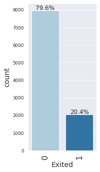

```python
# Observations on Exited
labeled_barplot(data, "Exited", True)
```

### Observations on Exited

- 79.6% (approx 8K) customers stays with bank
- 20.4% (approx 2K) customers left the bank
- imbalanced data, we can handle when building neural network model.

### Analysis on CreditScore

**Data Distribution**

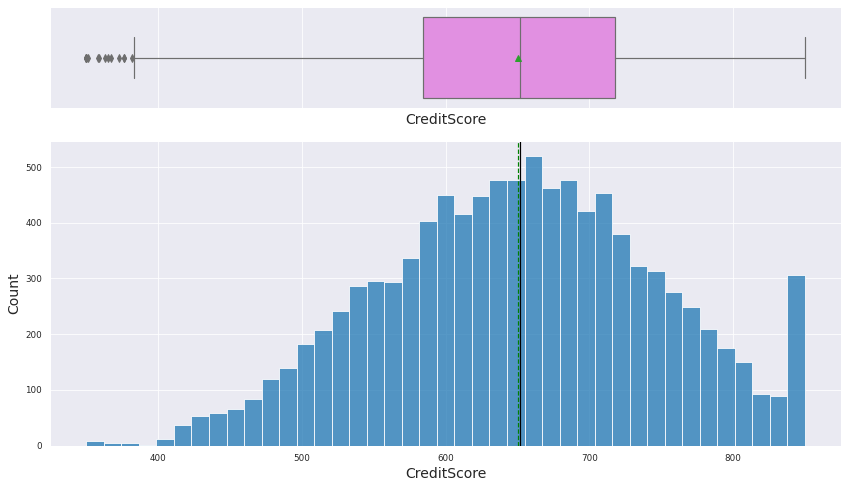

```python
# Observations on CreditScore
histogram_boxplot(data, "CreditScore")
```

**Checking Outliers**

```python
# checking outliers falls outside 3 times IQR Range
check_outlier_using_IQR("CreditScore", 3)
```

```
Column : CreditScore Outlier(s) check
Mean : 650.5288, Median : 652.0, Min : 350, Max : 850
Q1 = 584.0, Q3 = 718.0, 3*IQR = 402.0, Total Outlier(s) : 0

listing all outliers
Series([], Name: CreditScore, dtype: int64)
--------------------------------------------------
```

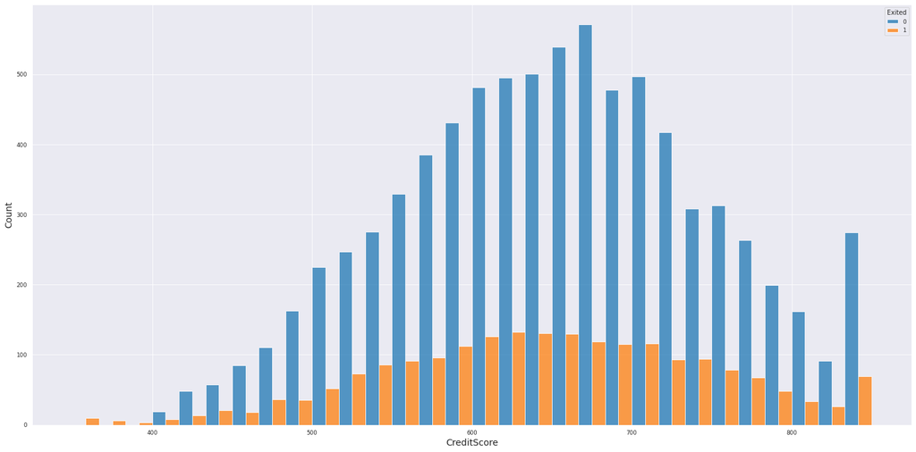

```python
#Checking CreditScore Relation with Exited Flag
plt.figure(figsize=(20, 10))
sns.histplot(data=data, x="CreditScore", hue="Exited", multiple="dodge",bins=30)
plt.show()
```

## Feature Engineering - New Feature `Credit Type` from Credit Score Ranges

Creating new feature credit type using credit score range.

- `Very Poor` - less than 300
- `Poor` - 300 to 579
- `Fair` - 580 to 669
- `Good` - 670 to 739
- `Very Good` - 740 to 799
- `Exceptional` - 800 and Above

```python
# Creating new feature Credit Type using Credit Score Ranges
data['CreditType'] = pd.cut(
    data['CreditScore'], [-np.inf, 580,670,740, 800, np.inf],
    labels = ["Poor","Fair","Good","Very Good","Exceptional"]
)
```

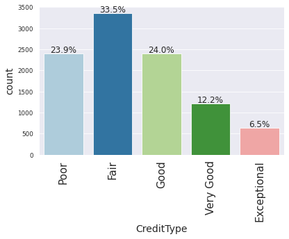

```python
# Observations on CreditType
labeled_barplot(data, "CreditType", True)
```

```
Exited          0     1    All
CreditType
All          7963  2037  10000
Fair         2667   683   3350
Poor         1863   530   2393
Good         1946   451   2397
Very Good     969   246   1215
Exceptional   518   127    645
------------------------------------------------------------------------------------------------------------------------
```

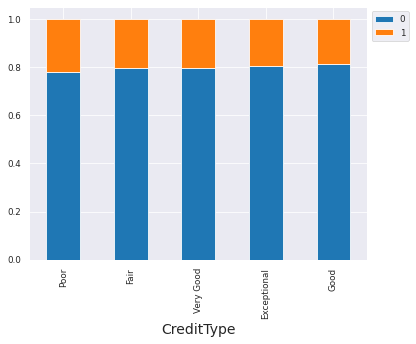

```python
# Observations on CreditType with Exited
stacked_barplot(data, "CreditType", "Exited")
```

### Observations on CreditType

- 24% customers has poor credit scores, 33.5% customers with fair, 24% with good, 12.2% with very good and 6.5% with exceptional scores
- Customer exit rate are little high in poor and fair score types compared with good to exceptional

### Analysis on Geography

**Data Distribution**

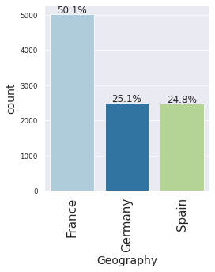

```python
# Observations on Geography
labeled_barplot(data, "Geography", True)
```

```
Exited        0     1    All
Geography
All        7963  2037  10000
Germany    1695   814   2509
France     4204   810   5014
Spain      2064   413   2477
------------------------------------------------------------------------------------------------------------------------
```

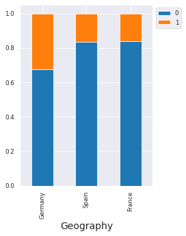

```python
# Observations on Geography with Exited
stacked_barplot(data, "Geography", "Exited")
```

### Observations on Geography

- We have 3 countries France, Germany & Spain.
- France has 50% data and Germany & Spain has 25% each
- Customers in Germany exists more compared to other countries.
- Customer country play important factor determine customer exit.
- 30% customers in germany exits bank compating with 15% yo 18% in Spain and France

### Analysis on Gender

**Data Distribution**

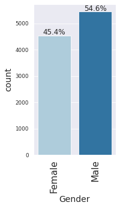

```python
# Observations on Gender
labeled_barplot(data, "Gender", True)
```

```
Exited     0     1    All
Gender
All     7963  2037  10000
Female  3404  1139   4543
Male    4559   898   5457
------------------------------------------------------------------------------------------------------------------------
```

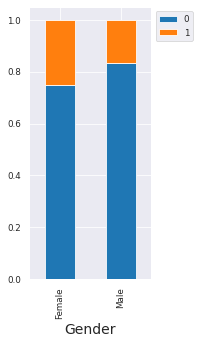

```python
# Observations on Gender with Exited
stacked_barplot(data, "Gender", "Exited")
```

### Observations on Gender

- We have 54.6% data for male & 45.4% data for female.
- Female exits more compared to Male
- Approx 25% female customers exits bank compared to 18% male customers

### Analysis on Age

**Data Distribution**

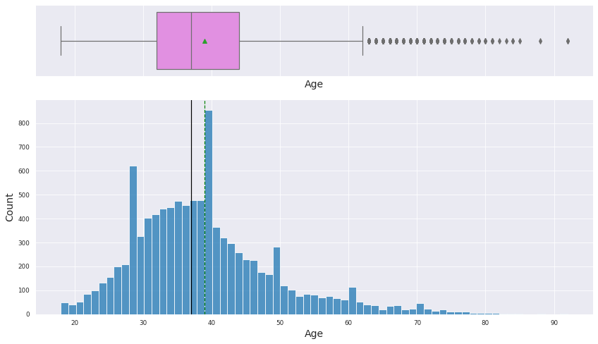

```python
# Observations on Age
histogram_boxplot(data, "Age")
```

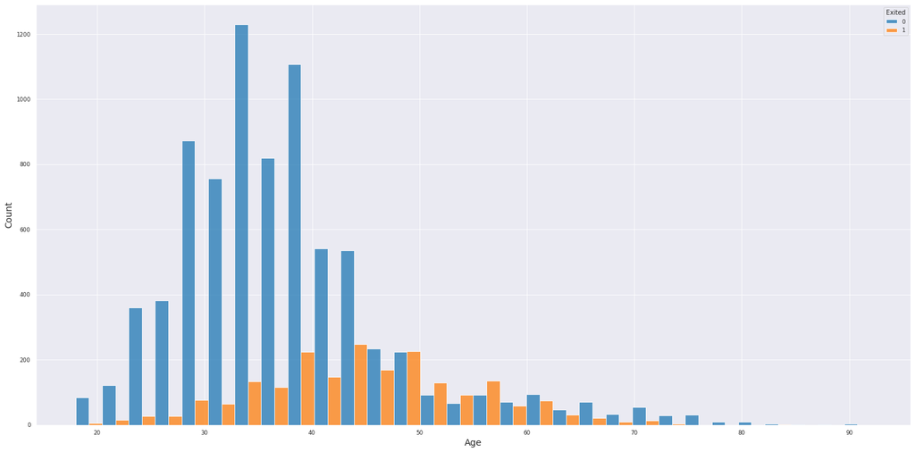

```python
#Checking Age Relation with Exited Flag
plt.figure(figsize=(20, 10))
sns.histplot(data=data, x="Age", hue="Exited", multiple="dodge",bins=30)
plt.show()
```

**Checking Outliers**

```python
# checking outliers falls outside 3 times IQR Range
check_outlier_using_IQR("Age", 3)
```

```
Column : Age Outlier(s) check
Mean : 38.9218, Median : 37.0, Min : 18, Max : 92
Q1 = 32.0, Q3 = 44.0, 3*IQR = 36.0, Total Outlier(s) : 72

listing 10 sample outliers
9587    76
3826    76
2925    76
310     80
1205    76
8217    75
4273    75
9736    78
4318    77
4256    76
Name: Age, dtype: int64
--------------------------------------------------
```

```python
# Checking customers shows as outliers
data[data["Age"]>70].sample(5)
```

|  | CreditScore | Geography | Gender | Age | Tenure | Balance | NumOfProducts | HasCrCard | IsActiveMember | EstimatedSalary | Exited | CreditType |
| --- | --- | --- | --- | --- | --- | --- | --- | --- | --- | --- | --- | --- |
| 1933 | 666 | Germany | Male | 74 | 7 | 105102.50 | 1 | 1 | 1 | 46172.47 | 0 | Fair |
| 1342 | 652 | Spain | Male | 71 | 4 | 0.00 | 1 | 1 | 1 | 120107.10 | 0 | Fair |
| 9324 | 780 | Germany | Male | 71 | 9 | 142550.25 | 2 | 1 | 1 | 122506.78 | 0 | Very Good |
| 6230 | 592 | France | Male | 71 | 4 | 0.00 | 2 | 0 | 1 | 17013.54 | 0 | Fair |
| 9490 | 624 | France | Male | 80 | 3 | 0.00 | 1 | 1 | 1 | 65801.44 | 0 | Fair |

### Observations on Age

- Mean is 39 and Median is 37. Mean and median has small difference
- Data show right tail skewness.
- 72 Customers falls outside 3 * IQR Range. But all are valid customers. No data adjustment required.
- After checking by Age we see most of the customers exited, Age plays a major role in churn prediction
- After Age 50 high chance customer might exit.
- Exit rate is very low below age 30

### Analysis on Tenure

**Data Distribution**

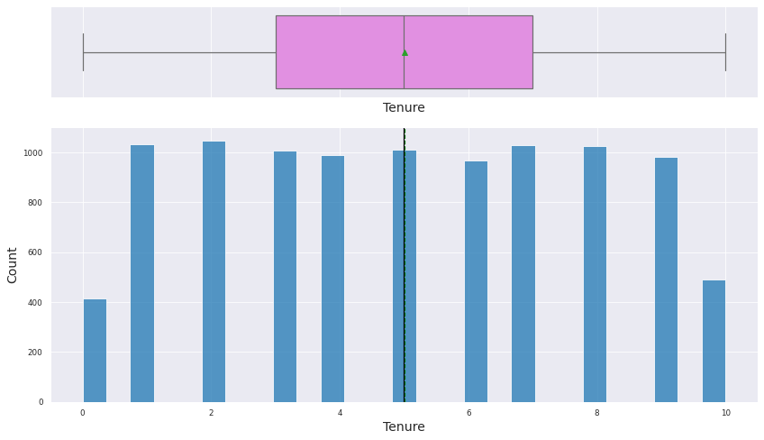

```python
# Observations on Tenure
histogram_boxplot(data, "Tenure")
```

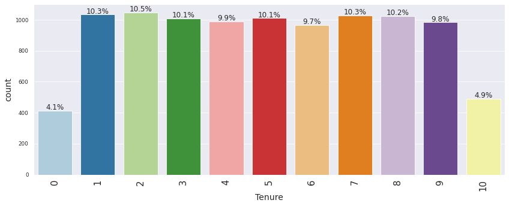

```python
# Observations on Tenure
labeled_barplot(data, "Tenure", True)
```

```
Exited     0     1    All
Tenure
All     7963  2037  10000
1        803   232   1035
3        796   213   1009
9        771   213    984
5        803   209   1012
4        786   203    989
2        847   201   1048
8        828   197   1025
6        771   196    967
7        851   177   1028
10       389   101    490
0        318    95    413
------------------------------------------------------------------------------------------------------------------------
```

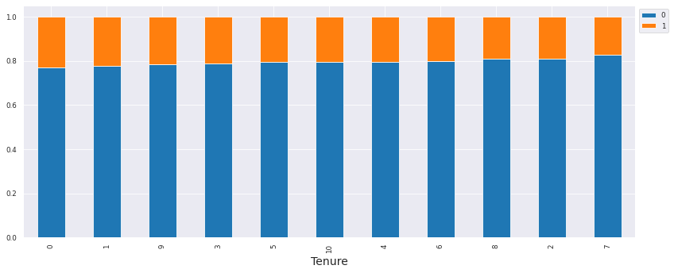

```python
# Observations on Tenure with Exited
stacked_barplot(data, "Tenure", "Exited")
```

### Observations on Tenure

- 90% Customers spread from 1 to 9 year, Each year has 10% to 11%
- 5% Customers is with 10 years & 4% customer with 0 years
- Customers with low tenure 0 & 1 has high exit rates(more than 20%), Compared with customer stay in bank for long

### Analysis on Balance

**Data Distribution**

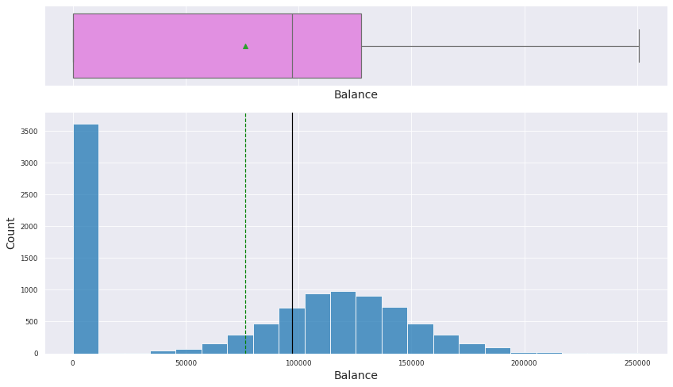

```python
# Observations on Balance
histogram_boxplot(data, "Balance")
```

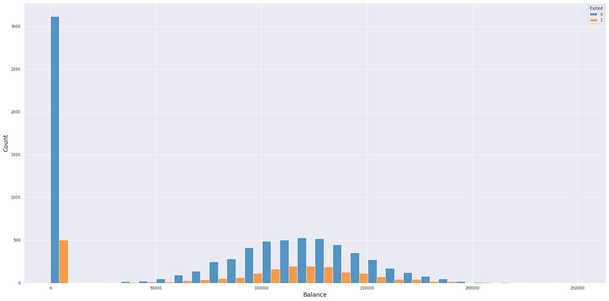

```python
#Checking Balance Relation with Exited Flag
plt.figure(figsize=(20, 10))
sns.histplot(data=data, x="Balance", hue="Exited", multiple="dodge",bins=30)
plt.show()
```

**Checking Outliers**

```python
# checking outliers falls outside 3 times IQR Range
check_outlier_using_IQR("Balance", 3)
```

```
Column : Balance Outlier(s) check
Mean : 76485.88928799961, Median : 97198.54000000001, Min : 0.0, Max : 250898.09
Q1 = 0.0, Q3 = 127644.24, 3*IQR = 382932.72000000003, Total Outlier(s) : 0

listing all outliers
Series([], Name: Balance, dtype: float64)
--------------------------------------------------
```

### Observations on Balance

- Shows small right tail, But data has no outliers
- 3500 customer has 0 balance
- Data is evenly distributed beyond balance 0
- Balance does not have any direct impact on customer exit.

### Analysis on NumOfProducts

**Data Distribution**

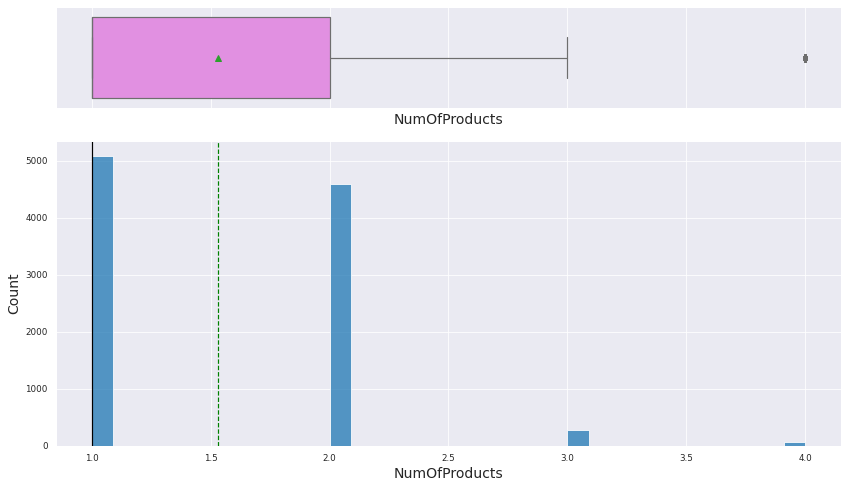

```python
# Observations on NumOfProducts
histogram_boxplot(data, "NumOfProducts")
```

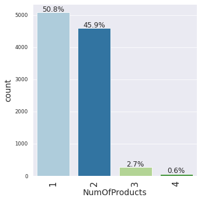

```python
# Observations on NumOfProducts
labeled_barplot(data, "NumOfProducts", True)
```

```
Exited            0     1    All
NumOfProducts
All            7963  2037  10000
1              3675  1409   5084
2              4242   348   4590
3                46   220    266
4                 0    60     60
------------------------------------------------------------------------------------------------------------------------
```

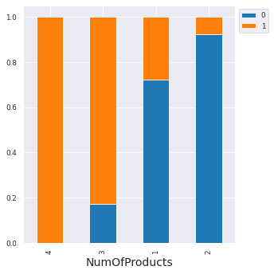

```python
# Observations on NumOfProducts with Exited
stacked_barplot(data, "NumOfProducts", "Exited")
```

### Observations on NumOfProducts

- only very few customers has 3 and 4 producus
- 97% customers has 1 or 2 product only
- Exit rate is very high with customers own 3 or 4 products.
- Exit rate is 100% with customers with 4 products.

### Analysis on HasCrCard

**Data Distribution**

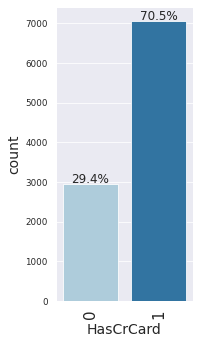

```python
# Observations on HasCrCard
labeled_barplot(data, "HasCrCard", True)
```

```
Exited        0     1    All
HasCrCard
All        7963  2037  10000
1          5631  1424   7055
0          2332   613   2945
------------------------------------------------------------------------------------------------------------------------
```

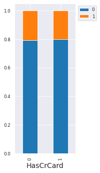

```python
# Observations on HasCrCard with Exited
stacked_barplot(data, "HasCrCard", "Exited")
```

### Observations on HasCrCard

- 70% customer has credit card, 30% has no credit card
- 20% csutomers exit on both has card or not.
- owning credit card does not influence exit rate sine exit rate % is same customer has card or not.

### Analysis on IsActiveMember

**Data Distribution**

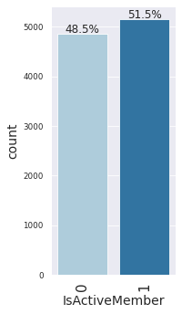

```python
# Observations on IsActiveMember
labeled_barplot(data, "IsActiveMember", True)
```

```
Exited             0     1    All
IsActiveMember
All             7963  2037  10000
0               3547  1302   4849
1               4416   735   5151
------------------------------------------------------------------------------------------------------------------------
```

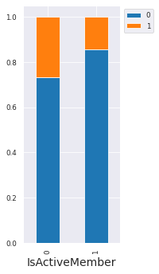

```python
# Observations on IsActiveMember with Exited
stacked_barplot(data, "IsActiveMember", "Exited")
```

### Observations on IsActiveMember

- 51.5% customers are active customers, 48.5% customers are marked as not active.
- Inactive customer has high exir rate compared to active customers.
- 25% Inactive customer exit bank compared to only 15% active customer leaving bank

### Analysis on EstimatedSalary

**Data Distribution**

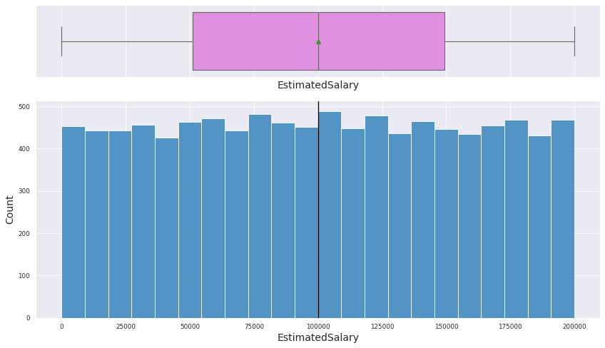

```python
# Observations on EstimatedSalary
histogram_boxplot(data, "EstimatedSalary")
```

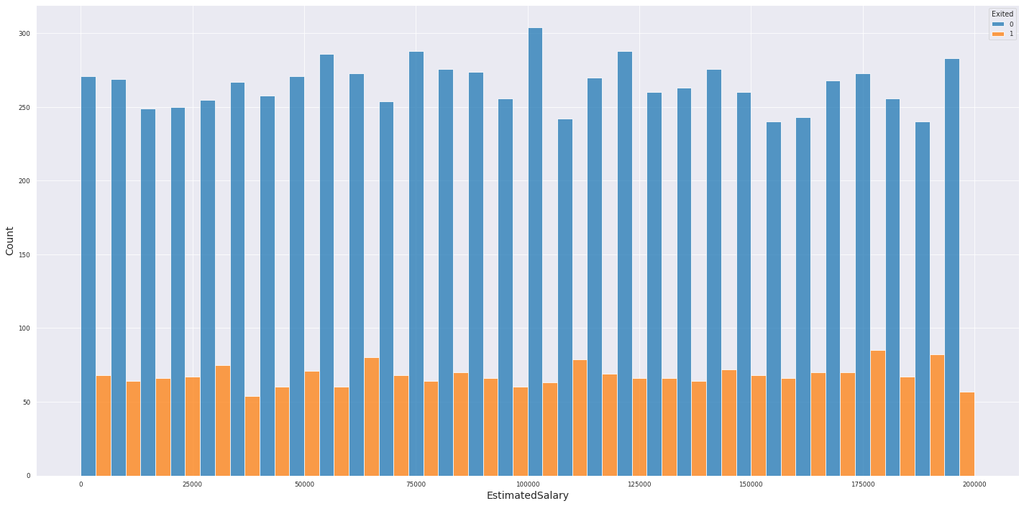

```python
#Checking EstimatedSalary Relation with Exited Flag
plt.figure(figsize=(20, 10))
sns.histplot(data=data, x="EstimatedSalary", hue="Exited", multiple="dodge",bins=30)
plt.show()
```

**Checking Outliers**

```python
# checking outliers falls outside 3 times IQR Range
check_outlier_using_IQR("EstimatedSalary", 3)
```

```
Column : EstimatedSalary Outlier(s) check
Mean : 100090.2398809998, Median : 100193.915, Min : 11.58, Max : 199992.48
Q1 = 51002.11, Q3 = 149388.2475, 3*IQR = 295158.4125, Total Outlier(s) : 0

listing all outliers
Series([], Name: EstimatedSalary, dtype: float64)
--------------------------------------------------
```

### Observations on EstimatedSalary

- No outliers in esimated salary.
- Mean and Median are same. That shows data is evenly distributed.
- Estimated salary does not show any relation with exit rates. Estimated salary does not influence customer exit.

## Bivariate Analysis

### Data correlation analysis - Heatmap

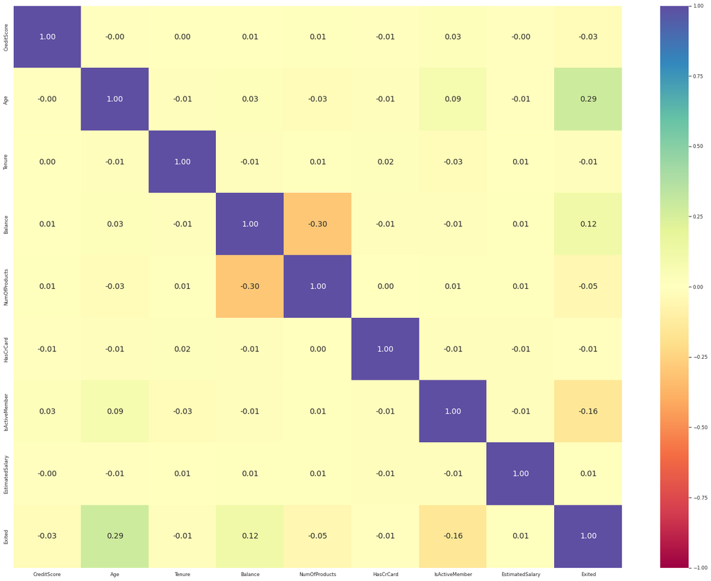

```python
plt.figure(figsize=(20, 15))
sns.heatmap(data.corr(), annot=True, vmin=-1, vmax=1, fmt=".2f", cmap="Spectral")
plt.show()
```

### Pair Plot analysis

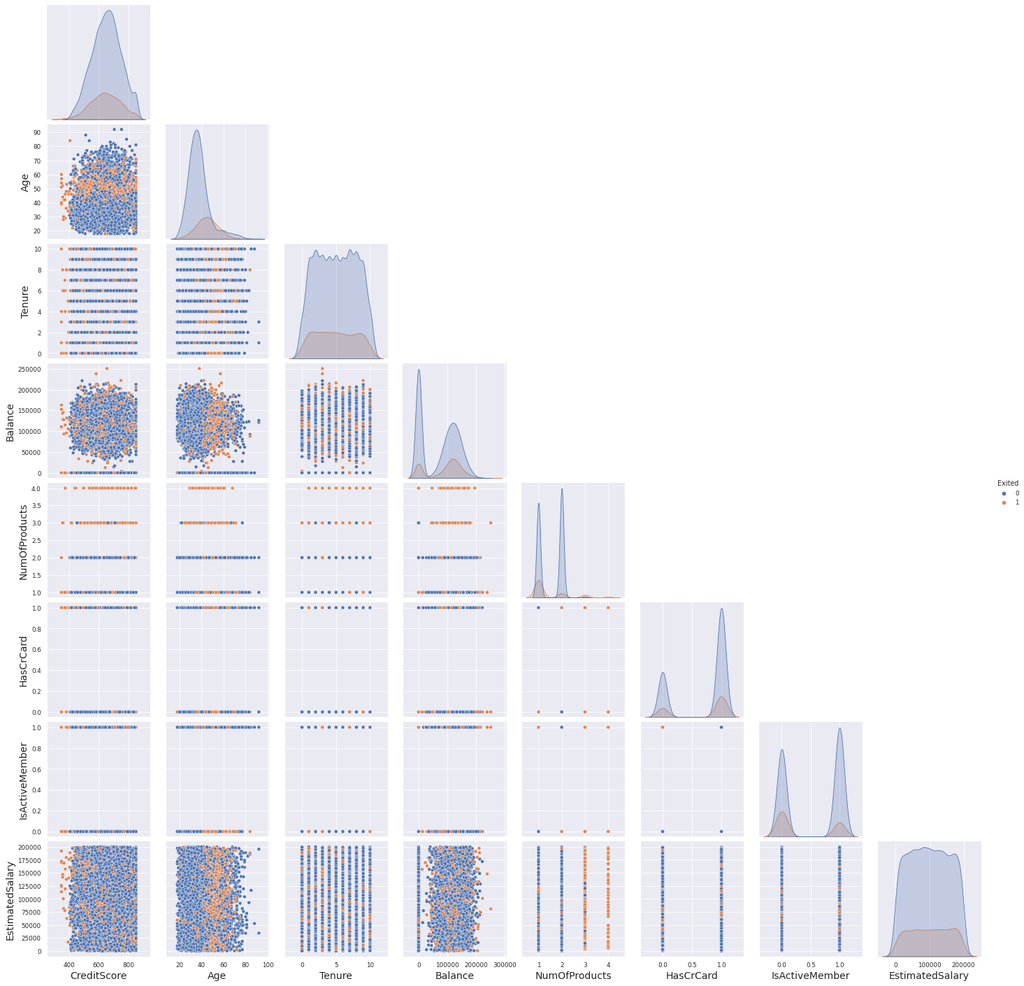

```python
plt.figure(figsize=(30, 15))
sns.pairplot(data, corner=True, palette="deep", hue="Exited")
plt.show()
```

## Analysis on Feature showing relation

### Balance vs NumOfProducts

```
Genrating Charts for feature x : NumOfProducts, y : Balance
```

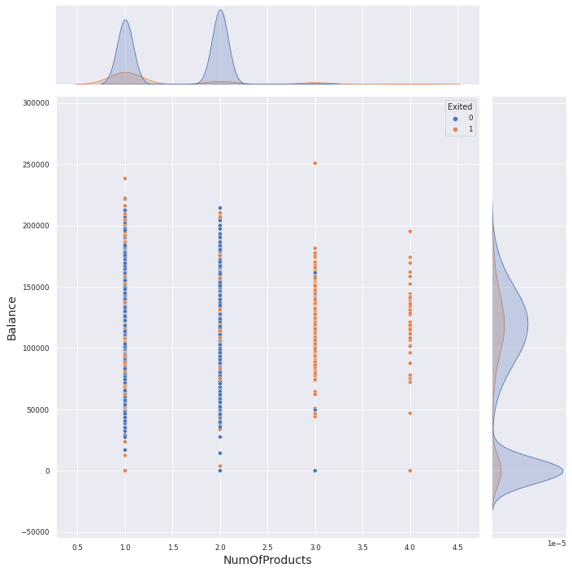

```python
# Checking Balance vs NumOfProducts Made with Exits
generate_bivariate_chart(
    xfeature="NumOfProducts",
    yfeature="Balance",
    data=data,
    hue="Exited",
)
```

### Key Observations on Balance vs NumOfProducts

- Exit rate is very high with customer owns 3 or 4. Every customer with 4 product exit bank
- Customer with 1 or 2 product does not show high exit rate.

### Age vs IsActiveMember

```
Genrating Charts for feature x : Age, y : IsActiveMember
```

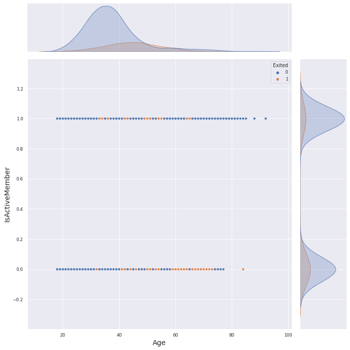

```python
# Checking Age vs IsActiveMember Made with Exits
generate_bivariate_chart(
    xfeature="Age",
    yfeature="IsActiveMember",
    data=data,
    hue="Exited",
)
```

### Key Observations on Age vs IsActiveMember

- Age group 40 to 70 has very high inactive members and high exit rates

### Balance vs EstimatedSalary

```
Genrating Charts for feature x : Balance, y : EstimatedSalary
```

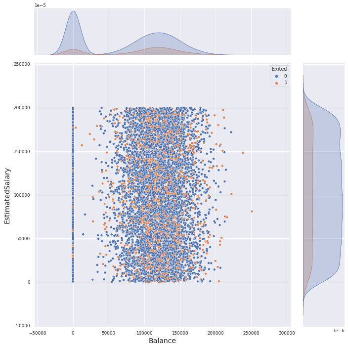

```python
# Checking Balance vs EstimatedSalary Made with Exits
generate_bivariate_chart(
    xfeature="Balance",
    yfeature="EstimatedSalary",
    data=data,
    hue="Exited",
)
```

### Key Observations on Balance vs EstimatedSalary

- Balance and Estimated Salary does not have any direct relation.
- Cusotmer exit is spread accross all balance range and salary range. Salary and Balance does not influence customer exit.

### NumOfProducts vs EstimatedSalary

```
Genrating Charts for feature x : EstimatedSalary, y : NumOfProducts
```

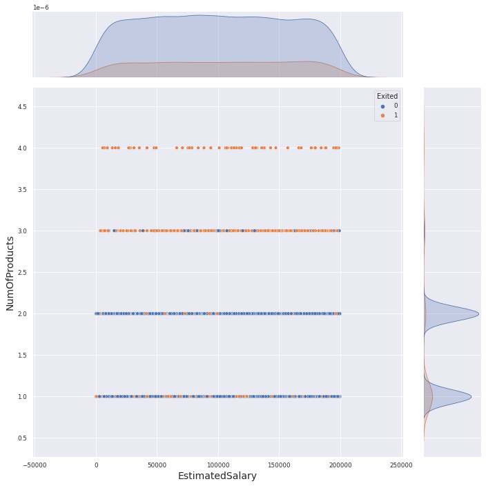

```python
# Checking NumOfProducts vs EstimatedSalary Made with Exits
generate_bivariate_chart(
    xfeature="EstimatedSalary",
    yfeature="NumOfProducts",
    data=data,
    hue="Exited",
)
```

### Key Observations on NumOfProducts vs EstimatedSalary

- All salary range customer with 3 or 4 product exit more compared with 1 or 2 product.

# Insights based on EDA

### Feature Engineering

- Created new feature credit type using credit score range.
- Credit Types are `Very Poor` - less than 300,`Poor` - 300 to 579, `Fair` - 580 to 669, `Good` - 670 to 739, `Very Good` - 740 to 799, `Exceptional` - 800 and Above

### Feature Elimination

- `Feature Elimination` - We dropped Remove features not reqd for churn prediction solution. Removing RowNumber, CustomerId & Surname these features does not influence churn prediction

### Customer Exit

- 79.6% (approx 8K) customers stays with bank
- 20.4% (approx 2K) customers left the bank

### Credit Type

- 24% customers has poor credit scores, 33.5% customers with fair, 24% with good, 12.2% with very good and 6.5% with exceptional scores
- Customer exit rate are little high in poor and fair score types compared with good to exceptional

### Geography

- We have 3 countries France, Germany & Spain.
- France has 50% data and Germany & Spain has 25% each
- Customers in Germany exists more compared to other countries.
- Customer country play important factor determine customer exit.
- 30% customers in germany exits bank compating with 15% yo 18% in Spain and France

### Gender

- We have 54.6% data for male & 45.4% data for female.
- Female exits more compared to Male
- Approx 25% female customers exits bank compared to 18% male customers

### Age

- Mean is 39 and Median is 37. Mean and median has small difference
- Data show right tail skewness.
- 72 Customers falls outside 3 * IQR Range. But all are valid customers. No data adjustment required.
- After checking by Age we see most of the customers exited, Age plays a major role in churn prediction
- After Age 50 high chance customer might exit.
- Exit rate is very low below age 30

### Tenure

- 90% Customers spread from 1 to 9 year, Each year has 10% to 11%
- 5% Customers is with 10 years & 4% customer with 0 years
- Customers with low tenure 0 & 1 has high exit rates(more than 20%), Compared with customer stay in bank for long

### Balance

- Shows small right tail, But data has no outliers
- 3500 customer has 0 balance
- Data is evenly distributed beyond balance 0
- Balance does not have any direct impact on customer exit.

### Number Of Products

- only very few customers has 3 and 4 producus
- 97% customers has 1 or 2 product only
- Exit rate is very high with customers own 3 or 4 products.
- Exit rate is 100% with customers with 4 products.

### Has Credit Card

- 70% customer has credit card, 30% has no credit card
- 20% csutomers exit on both has card or not.
- owning credit card does not influence exit rate sine exit rate % is same customer has card or not.

### Is Active Member

- 51.5% customers are active customers, 48.5% customers are marked as not active.
- Inactive customer has high exir rate compared to active customers.
- 25% Inactive customer exit bank compared to only 15% active customer leaving bank

### Estimated Salary

- No outliers in esimated salary.
- Mean and Median are same. That shows data is evenly distributed.
- Estimated salary does not show any relation with exit rates. Estimated salary does not influence customer exit.

### Exited

- 79.6% (approx 8K) customers stays with bank
- 20.4% (approx 2K) customers left the bank
- imbalanced data, we can handle when building neural network model.

## Key Observations from Bivariate Analysis

### Key Observations on Balance vs NumOfProducts

- Exit rate is very high with customer owns 3 or 4. Every customer with 4 product exit bank
- Customer with 1 or 2 product does not show high exit rate.

### Key Observations on Age vs IsActiveMember

- Age group 40 to 70 has very high inactive members and high exit rates

### Key Observations on Balance vs EstimatedSalary

- Balance and Estimated Salary does not have any direct relation.
- Cusotmer exit is spread accross all balance range and salary range. Salary and Balance does not influence customer exit.

### Key Observations on NumOfProducts vs EstimatedSalary

- All salary range customer with 3 or 4 product exit more compared with 1 or 2 product.

# Data Pre-processing

### Data Preparation for Modeling

- Creating Dummy Variables for category type features
- Separating Dependent feature and other features

```python
# Separating target variable and other variables

# Dropping CreditScore since we added new category credit type.
# Dropping Exited since its a dependent feature

#X = data.drop(["CreditScore","Exited"],axis=1)
X = data.drop(["CreditType","Exited"],axis=1)


# Adding Dependent Feature Exited

Y = data["Exited"]

# Checking Shape of X & Y and Count of Exit Yes and No

print(f"Shape of X: {X.shape}, And Y: {Y.shape}")
print("Y feature, counts of label 'Yes': {}".format(sum(Y == 1)))
print("Y feature, counts of label 'No': {} \n".format(sum(Y == 0)))

X = pd.get_dummies(X, drop_first=False)
print(f"After one hot encoding - Shape of X: {X.shape}")
```

```
Shape of X: (10000, 10), And Y: (10000,)
Y feature, counts of label 'Yes': 2037
Y feature, counts of label 'No': 7963

After one hot encoding - Shape of X: (10000, 13)
```

```python
X.head(5)
```

|  | CreditScore | Age | Tenure | Balance | NumOfProducts | HasCrCard | IsActiveMember | EstimatedSalary | Geography_France | Geography_Germany | Geography_Spain | Gender_Female | Gender_Male |
| --- | --- | --- | --- | --- | --- | --- | --- | --- | --- | --- | --- | --- | --- |
| 0 | 619 | 42 | 2 | 0.00 | 1 | 1 | 1 | 101348.88 | 1 | 0 | 0 | 1 | 0 |
| 1 | 608 | 41 | 1 | 83807.86 | 1 | 0 | 1 | 112542.58 | 0 | 0 | 1 | 1 | 0 |
| 2 | 502 | 42 | 8 | 159660.80 | 3 | 1 | 0 | 113931.57 | 1 | 0 | 0 | 1 | 0 |
| 3 | 699 | 39 | 1 | 0.00 | 2 | 0 | 0 | 93826.63 | 1 | 0 | 0 | 1 | 0 |
| 4 | 850 | 43 | 2 | 125510.82 | 1 | 1 | 1 | 79084.10 | 0 | 0 | 1 | 1 | 0 |

### Splitting data into training and test

```python
from sklearn.model_selection import train_test_split

# Splitting data into training and test set

X_train, X_test, y_train, y_test = train_test_split(
    X, Y, test_size=0.1, random_state=42, stratify=Y
)


# Checking Shape of X_train & X_test and Count of Exit Yes and No

print(f"Shape of X_train: {X_train.shape}, And X_test: {X_test.shape}")
print(X_train.shape, X_test.shape)

print("y_train % of 0 & 1")
y_train.value_counts(normalize=True)
```

```
Shape of X_train: (9000, 13), And X_test: (1000, 13)
(9000, 13) (1000, 13)
y_train % of 0 & 1
```

```
0    0.796333
1    0.203667
Name: Exited, dtype: float64
```

### Standardization, or mean removal and variance scaling

`Standardization` of datasets is a common requirement for many machine learning estimators implemented in scikit-learn; they might behave badly if the individual features do not more or less look like standard normally distributed data: Gaussian with zero mean and unit variance.

```python
from sklearn.preprocessing import StandardScaler

# Define the scaler
scaler = StandardScaler().fit(X_train)

# Scale the train set
X_train = scaler.transform(X_train)

# Scale the test set
X_test = scaler.transform(X_test)
```

```python
#Checking Data after Standardization
pd.DataFrame(X_train, columns=X.columns).describe().T
```

|  | count | mean | std | min | 25% | 50% | 75% | max |
| --- | --- | --- | --- | --- | --- | --- | --- | --- |
| CreditScore | 9000.0 | -2.287059e-17 | 1.000056 | -3.112811 | -0.691320 | 0.012362 | 6.953462e-01 | 2.061315 |
| Age | 9000.0 | 2.685013e-16 | 1.000056 | -1.994498 | -0.660407 | -0.183946 | 4.830998e-01 | 5.057126 |
| Tenure | 9000.0 | -2.103996e-16 | 1.000056 | -1.735994 | -0.698685 | -0.007146 | 1.030163e+00 | 1.721702 |
| Balance | 9000.0 | 1.194847e-16 | 1.000056 | -1.226513 | -1.226513 | 0.333455 | 8.214001e-01 | 2.596915 |
| NumOfProducts | 9000.0 | 5.255796e-16 | 1.000056 | -0.908447 | -0.908447 | -0.908447 | 8.102885e-01 | 4.247761 |
| HasCrCard | 9000.0 | -6.834286e-16 | 1.000056 | -1.552957 | -1.552957 | 0.643933 | 6.439328e-01 | 0.643933 |
| IsActiveMember | 9000.0 | -4.477406e-16 | 1.000056 | -1.028403 | -1.028403 | 0.972381 | 9.723812e-01 | 0.972381 |
| EstimatedSalary | 9000.0 | 9.725554e-17 | 1.000056 | -1.734407 | -0.853538 | -0.002863 | 8.533572e-01 | 1.750085 |
| Geography_France | 9000.0 | 2.677858e-16 | 1.000056 | -1.003116 | -1.003116 | 0.996894 | 9.968937e-01 | 0.996894 |
| Geography_Germany | 9000.0 | 4.917548e-16 | 1.000056 | -0.574955 | -0.574955 | -0.574955 | -5.749553e-01 | 1.739266 |
| Geography_Spain | 9000.0 | 1.279964e-16 | 1.000056 | -0.577350 | -0.577350 | -0.577350 | -5.551115e-17 | 1.732051 |
| Gender_Female | 9000.0 | -2.785179e-16 | 1.000056 | -0.911867 | -0.911867 | -0.911867 | 1.096651e+00 | 1.096651 |
| Gender_Male | 9000.0 | 2.785179e-16 | 1.000056 | -1.096651 | -1.096651 | 0.911867 | 9.118672e-01 | 0.911867 |

### Oversampling train data using SMOTE

```python
# To oversample and undersample data
from imblearn.over_sampling import SMOTE
from imblearn.under_sampling import RandomUnderSampler
```

```python
print("Before Oversampling, counts of label 'Yes': {}".format(sum(y_train == 1)))
print("Before Oversampling, counts of label 'No': {} \n".format(sum(y_train == 0)))

sm = SMOTE(
    sampling_strategy=1, k_neighbors=5, random_state=1
)  # Synthetic Minority Over Sampling Technique
X_train_over, y_train_over = sm.fit_resample(X_train, y_train)


print("After Oversampling, counts of label 'Yes': {}".format(sum(y_train_over == 1)))
print("After Oversampling, counts of label 'No': {} \n".format(sum(y_train_over == 0)))


print("After Oversampling, the shape of train_X: {}".format(X_train_over.shape))
print("After Oversampling, the shape of train_y: {} \n".format(y_train_over.shape))
```

```
Before Oversampling, counts of label 'Yes': 1833
Before Oversampling, counts of label 'No': 7167

After Oversampling, counts of label 'Yes': 7167
After Oversampling, counts of label 'No': 7167

After Oversampling, the shape of train_X: (14334, 13)
After Oversampling, the shape of train_y: (14334,)
```

```python
print("y_test % of 0 & 1")
y_test.value_counts(normalize=True)
```

```
y_test % of 0 & 1
```

```
0    0.796
1    0.204
Name: Exited, dtype: float64
```

**All Data has been transformed and Standardized**

# Building Deep Neural Network Models

## Model evaluation criterion

### Model can make wrong predictions as:

- Predicting a customer exit bank and customer does not exit
- Predicting a customer will not exit bank but customer exit

### Which case is more important?

- Predicting customer will not exit bank but customer exit is costly, Since bank is losing customers.

### How to reduce this loss i.e need to reduce False Negative?

- Recall - Bank would want `Recall` to be maximized, greater the Recall higher the chances of minimizing false Negative. Hence, the focus should be on increasing Recall or minimizing the false Negative or in other words identifying the True Positive(i.e. Class 1) so that the Bank can identify the Customer Exits.

### Model Metrics - Performance

- `False Negatives :` Calculates the number of false negatives.
- `Loss :` Training and Validation loss
- `Accuracy :`Calculates how often predictions equal labels.
- `Precision :`Computes the precision of the predictions with respect to the labels.
- `Recall:`Computes the recall of the predictions with respect to the labels.
- `AUC :` Approximates the AUC (Area under the curve) of the ROC or PR curves.

## Converting the Numpy array into tensors

### Import all necessary tensorflow libraries

```python
#importing tensorflow
import tensorflow as tf

# Using Tensorflow Keras instead of the original Keras

from tensorflow.keras.datasets import mnist
from tensorflow.keras import Sequential
from tensorflow.keras.layers import Dense

print(tf.__version__)
```

```
2.7.0
```

### Building Methods to Plot Graphs for Loss & Score & Confusion matrix

```python
# creating common method to plot loss & recall for train & validation

def plot_loss_recall_graph(history):
  # Capturing learning history per epoch
  hist  = pd.DataFrame(history.history)
  hist['epoch'] = history.epoch

  # Plotting accuracy at different epochs
  #plt.plot(hist['loss'])
  #plt.plot(hist['val_loss'])
  #plt.legend(("train" , "valid") , loc =0)

  fig, (axs) = plt.subplots(2, 3, figsize=(25, 10))
  #fig.suptitle('Train and validation loss ')

  # Loss Metrics
  ax1 = axs[0,0]
  ax1.set_title('Loss Graph')
  ax1.set_xlabel('epoch(s)')
  ax1.set_ylabel('loss')

  ax1.plot(hist['loss'])
  ax1.plot(hist['val_loss'])
  ax1.legend(("train" , "val") , loc =0)




  # Recall metric
  ax2 = axs[0,1]
  ax2.set_title('Recall Score')
  ax2.set_xlabel('epoch(s)')
  ax2.set_ylabel('recall')

  ax2.plot(hist['recall'])
  ax2.plot(hist['val_recall'])
  ax2.legend(("train" , "val") , loc =0)


  # Accuracy metric
  ax3 = axs[0,2]
  ax3.set_title('Accuracy Score')
  ax3.set_xlabel('epoch(s)')
  ax3.set_ylabel('accuracy')

  ax3.plot(hist['accuracy'])
  ax3.plot(hist['val_accuracy'])
  ax3.legend(("train" , "val") , loc =0)


  # Precision Metrics
  ax4 = axs[1,0]
  ax4.set_title('Precision Score')
  ax4.set_xlabel('epoch(s)')
  ax4.set_ylabel('precision')

  ax4.plot(hist['precision'])
  ax4.plot(hist['val_precision'])
  ax4.legend(("train" , "val") , loc =0)


  # False Negative
  ax5 = axs[1,1]
  ax5.set_title('False Negative')
  ax5.set_xlabel('epoch(s)')
  ax5.set_ylabel('false_negative')

  ax5.plot(hist['false_negative'])
  ax5.plot(hist['val_false_negative'])
  ax5.legend(("train" , "val") , loc =0)

  # Area under the PR curves
  ax6 = axs[1,2]
  ax6.set_title('AUC PR curves')
  ax6.set_xlabel('epoch(s)')
  ax6.set_ylabel('auc_pr')

  ax6.plot(hist['auc_pr'])
  ax6.plot(hist['val_auc_pr'])
  ax6.legend(("train" , "val") , loc =0)




def evaluate_model(model,history,x_test_eval, y_test_eval):
  score = model.evaluate(x_test_eval, y_test_eval)
  print(f"Model Score - {model.name}")
  print(score)
  print()
  plot_loss_recall_graph(history)

def show_model_performance(model, history,  X_train,
          y_train,
          X_test,
          y_test):
  display(
      model_performance_classification(
          model.name,
          model,
          X_train,
          y_train,
          X_test,
          y_test,
      )
  )

  confusion_matrix_classification(
          model.name,
          model, X_train, y_train, X_test, y_test
  )

  print()
  print()
  evaluate_model(model,history, X_test,y_test)
```

```python
from sklearn.metrics import confusion_matrix, classification_report
from sklearn.metrics import accuracy_score,precision_score,recall_score,f1_score
from sklearn.metrics import roc_auc_score

# defining a function to compute different metrics to check performance of a classification model built using sklearn
def model_performance_classification(name, model,train_x_data,train_y_data,val_x_data,val_y_data):
    """
    Function to compute different metrics to check classification model performance

    model: classifier
    predictors: independent variables
    target: dependent variable
    """

    #print(f"Model '{name}' performance \n\n")

    predictors_train = train_x_data
    target_train = train_y_data

    predictors_test = val_x_data
    target_test = val_y_data

    # predicting training data using the independent variables
    pred_train = model.predict(predictors_train)

    for i in range(len(pred_train)):
      if pred_train[i]>0.5:
          pred_train[i]=1
      else:
          pred_train[i]=0

    acc_train = accuracy_score(target_train, pred_train)  # to compute Accuracy
    recall_train = recall_score(target_train, pred_train)  # to compute Recall
    precision_train = precision_score(target_train, pred_train)  # to compute Precision
    f1_train = f1_score(target_train, pred_train)  # to compute F1-score
    roc_train = roc_auc_score(target_train, pred_train)  # to compute ROC AUC

    # predicting test data using the independent variables
    pred_test = model.predict(predictors_test)

    for i in range(len(pred_test)):
      if pred_test[i]>0.5:
          pred_test[i]=1
      else:
          pred_test[i]=0

    acc_test = accuracy_score(target_test, pred_test)  # to compute Accuracy
    recall_test = recall_score(target_test, pred_test)  # to compute Recall
    precision_test = precision_score(target_test, pred_test)  # to compute Precision
    f1_test = f1_score(target_test, pred_test)  # to compute F1-score
    roc_test = roc_auc_score(target_test, pred_test)  # to compute ROC AUC

    # creating a dataframe of metrics
    df_perf = pd.DataFrame(
        [
            {
                "Model": name,
                "Data":"Training",
                "Data Shape":train_x_data.shape,
                "Recall": np.round_(recall_train * 100, decimals=3),
                "F1-Score": np.round_(f1_train * 100, decimals=3),
                "Accuracy": np.round_(acc_train * 100, decimals=3),
                "Precision": np.round_(precision_train * 100, decimals=3),
                "ROC-AUC": np.round_(roc_train * 100, decimals=3),
            },{  "Model": name,
                "Data":"Test",
                "Data Shape":val_x_data.shape,
                "Recall": np.round_(recall_test * 100, decimals=3),
                "F1-Score": np.round_(f1_test * 100, decimals=3),
                "Accuracy": np.round_(acc_test * 100, decimals=3),
                "Precision": np.round_(precision_test * 100, decimals=3),
                "ROC-AUC": np.round_(roc_test * 100, decimals=3),
            },
        ]
    )
    return df_perf

def confusion_matrix_classification(name, model,train_x_data,train_y_data,val_x_data,val_y_data):
    """
    To plot the confusion_matrix with percentages

    model: classifier
    predictors: independent variables
    target: dependent variable
    """
    sns.set_context(
        "paper", rc={"font.size": 14, "axes.titlesize": 14, "axes.labelsize": 14}
    )
    print(f"Model '{name}' confusion matrix \n\n")

    predictors_train = train_x_data
    target_train = train_y_data

    predictors_test = val_x_data
    target_test = val_y_data
    #predictors_output = test_y_data.copy()

    y_pred_train = model.predict(predictors_train)
    y_pred_test = model.predict(predictors_test)




    for i in range(len(y_pred_train)):
      if y_pred_train[i]>0.5:
          y_pred_train[i]=1
      else:
          y_pred_train[i]=0


    for i in range(len(y_pred_test)):
      if y_pred_test[i]>0.5:
          y_pred_test[i]=1
      else:
          y_pred_test[i]=0

    cm_train = confusion_matrix(target_train, y_pred_train)
    cm_test = confusion_matrix(target_test, y_pred_test)

    #predictors_output['Orig'] = target_test
    #predictors_output['Model'] = y_pred_test

    plt.rcParams["figure.figsize"] = [12, 6]
    plt.rcParams["figure.autolayout"] = True

    f, axes = plt.subplots(1, 2)

    labels = np.asarray(
        [
            [
                "{0:0.0f}".format(item)
                + "\n{0:.2%}".format(item / cm_train.flatten().sum())
            ]
            for item in cm_train.flatten()
        ]
    ).reshape(2, 2)

    labels_test = np.asarray(
        [
            [
                "{0:0.0f}".format(item)
                + "\n{0:.2%}".format(item / cm_test.flatten().sum())
            ]
            for item in cm_test.flatten()
        ]
    ).reshape(2, 2)

    g = sns.heatmap(cm_train, annot=labels, fmt="", ax=axes[0])
    g.set(xlabel="True label", ylabel="Predicted label", title="Training Data")

    g1 = sns.heatmap(cm_test, annot=labels_test, fmt="", ax=axes[1])
    g1.set(xlabel="True label", ylabel="Predicted label", title="Test Data")
```

```python
#printing the shape of training tensor
nrows,ncols = X_train.shape

nrows,ncols
```

[output not shown]